# Final Paper

STOR 320.01, Group 2

July 26, 2019

# **An Investigation into Dead and Missing Migrants in Northern America**

# INTRODUCTION

The International Organization for Migration’s Missing Migrants Project aims to track dead and missing migrants during various migrations around the world between 2014 and 2019. The animated map displays the change in number and locations of all these incidents across the time period. From the collected data, we were particularly interested in investigating the effect Donald Trump’s presidency would have on migration incidents along and near the U.S. border. Effectively, we wanted to analyze and predict whether or not a migration incident – be it a death or missing migrant – occurred before or after Donald Trump’s inauguration and his ensuing policies based on two variables – source quality and the number of dead and missing migrants. Donald Trump took office in January of 2017, so, we hoped to find particular trends before and after this month. It was important to note a few political events and policies put into place. As it relates to migration via U.S. borders, President Trump ordered 2,000 National Guard troops to the U.S.-Mexico border in April of 2018. He furthered this a few months later and sent 5,200 National Guard troops to the U.S.-Mexico border in October of 2018. President Trump also demanded that Mexico better protect its side of the U.S.-Mexico border at the start of 2019 (Ballotpedia.org). And while President Trump was insistent on limiting refugees into the U.S. from countries like Syria, all while trying to eliminate sanctuary cities in the U.S., these policies do not impact our model and interest into predicting whether a migration incident occurred before or after President Trump’s inauguration of incidents based on source quality and number of incidents.

Additionally, we wanted to construct a time series of the number of dead and missing migrants from 2014 to 2019 in order to create an ARIMA forecasting model. However, there were significant events that took place while President Obama was in office. Notably, U.S. Customs and Border Protection took extreme action under President Obama in both stopping and deporting migrants at the U.S.-Mexico border, especially in the spring of 2014 and the end of 2015. A Pew Research study notes that “a more recent rise in the number of apprehensions at the U.S.-Mexico border” (Pew Research). For instance, “more than 60,000 unaccompanied children arrived at the southern border in 2014” (NPR). With these two questions of interest and models we hoped to observe patterns in migration incidents over the past five years and how President Donald Trump has affected migration incidents, if at all.

###### *Figure 1*

##### **Deaths Worldwide Year-Over-Year**

[figure not shown]

We hoped to answer the following two questions that would serve to benefit readers:

1. Can we forecast the number of dead and missing migrants at the U.S.-Mexico Border based on previous patterns or trends?
2. Can we predict whether or not an incident would occur in northern America before or after Donald Trump’s inauguration?

While we were certainly interested in jumping into these questions, we also thought the vast majority of people would also find them interesting, especially in the United States. Simply put, not a day goes by where President Trump is not in the news in one way or another. Thus, we found this an applicable and fascinating topic to dive in to. Beyond President Trump and his policies, immigration has become a very important and pressing issue globally. One of the biggest immigration debates centers around Syrian refugees. Thousands of Syrians have fled their native country and scattered throughout Europe by way of the Mediterranean Sea. All told, immigration – and thus, migration trends – have been at the forefront of current events and politics around the globe. As more and more refugees seek asylum, the burden that weighs on the countries that accept these refugees becomes heavier. As these countries reach their limit for how many refugees they can accept, some European countries are refusing to rescue refugees, which may cause the number of missing and dead refugees to rise (NPR). The analysis of our data is especially useful to understand the change in the number of dead and missing migrants, which can reflect changing global policies and politics.

With that said, one may definitely benefit from our analyses because of the importance of current events. We honed in on three regions that are directly affected by President Trump’s policies – the U.S.-Mexico border, Central America, and the Caribbean. President Trump wants to fortify the United States’ borders. So, migration data from these three regions is affected by the policies of the United States. Using this data and predictions can help one decipher whether or not to implement certain policies – political or not. Migration trends and patterns – particularly, around the United States and given the current political climate – impact thousands of individuals. Moreover, immigration and emigration has a profound impact on social and economic conditions. With this data and analyzing trends, we observe if we can make any predictions. An owner of the data is then able to make thoughtful decisions as to whether social, economic, or political action needs to be taken, depending on their industry and interests.

# DATA

Before delving into the two questions, our group first tidied the large dataset into a more meaningful presentation. Overall, there were 5,333 observations, each corresponding to a recorded incident, and 20 variables collected from 12 different regions between 2014 and 2019. For consistency, we assigned NA values to all empty cells to denote missing values.

###### *Table 1*

##### **Total Dead and Missing per Region** **(Before and After Jan. 2017)**

| Region | Pre-Trump | Post-Trump | Total |
| --- | --- | --- | --- |
| Caribbean | 256 | 243 | 499 |
| Central America | 406 | 213 | 619 |
| US-Mexico Border | 1046 | 918 | 1964 |
| Grand Total | 1708 | 1374 | 3082 |

Since we are particularly interested in the influence of Trump’s presidency on migration, we created a new variable to recode the reported years provided by the Missing Migrants Project as a binary variable. Specifically, all incidents that occurred after Donald Trump took office in 2017 were assigned a ‘1’, and those incidents that occurred before he took office were assigned a ‘0’. Table 1 refers to the number of incidents of dead or missing migrants in the US-Mexico border, the Caribbean, and Central America before Donald Trump assumed office. Based on the counts in Table 1, we noticed two things: the majority of dead and missing migrants happened at the U.S.-Mexico border and more dead and missing incidents occurred before Donald Trump took office but over a longer period of time. Following this finding, we continued our analysis and model-building more effectively.

###### *Figure 2*

##### **Distribution of Source Quality by Region and Year**

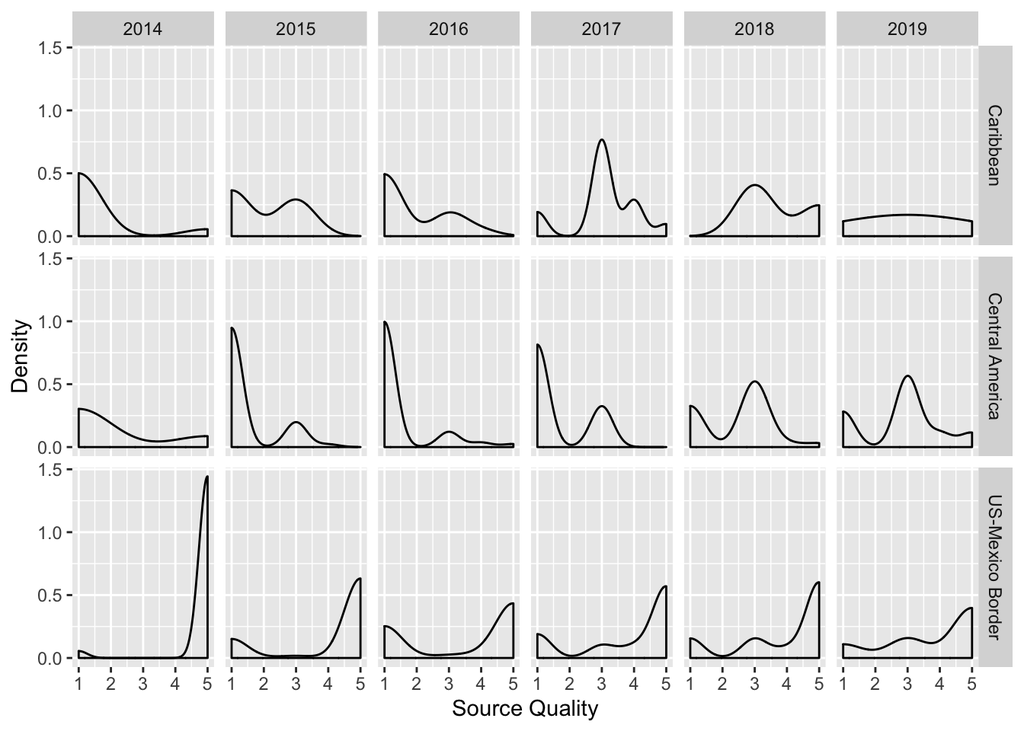

###### *Figure 3*

##### **Number of Dead and Missing by Region per Year**

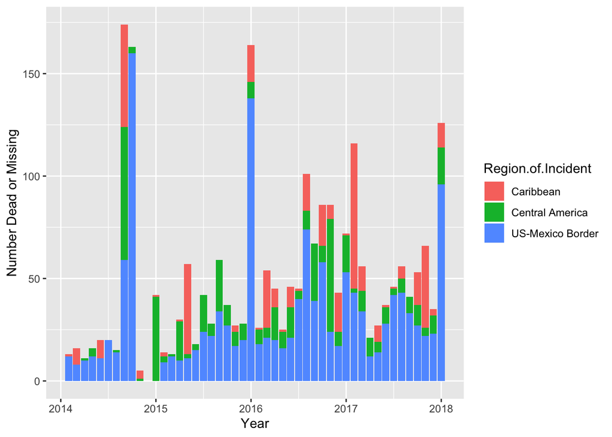

# RESULTS

###### *Figure 4*

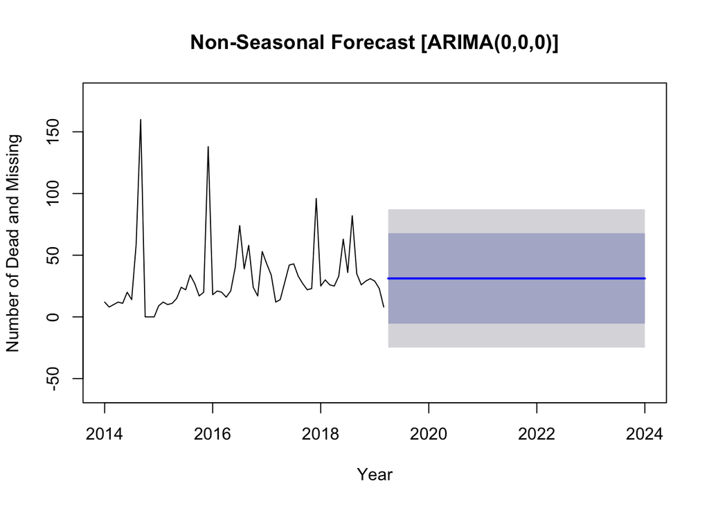

###### *Figure 5*

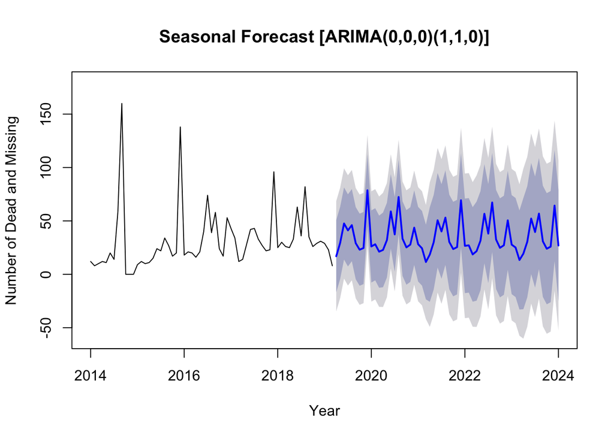

Our first question asked if it is possible to forecast the number of dead and missing migrants from some pattern or trend in previous years’ data. Since we expected a seasonal pattern in the change of the number of dead and missing migrants, we forced seasonality for our first ARIMA model (Figure 5). The output from the forced seasonality auto-ARIMA model forecasted some seasonal pattern and white noise (0,0,0). “White noise” indicates that there is no consistent pattern in the data that can be used to predict future changes, so the forced seasonality ARIMA model cannot forecast the number of dead and missing migrants. The unforced season ARIMA plot only displayed white noise(0,0,0), which means that this model cannot be used to forecast the number of dead and missing migrants (Figure 4). Regardless of forced or unforced seasonality, both models did a poor job predicting the number of dead and missing migrants.

###### *Table 2*

##### **Logistic Regression Model without Interactions**

| Predictors | Coefficients | P-Values |
| --- | --- | --- |
| Source Quality | 0.14 | 0.003 |
| Total Dead and Missing | -0.14 | 0.039 |

###### *Table 3*

##### **Sensitivity and Specificity for KNN** **with k=21 and Logistic Regression**

| Model | KNN | Logistic |
| --- | --- | --- |
| Sensitivity | 0.78 | 0.77 |
| Specitvity | 0.41 | 0.41 |
| False Positive Rate | 0.59 | 0.59 |
| False Negative Rate | 0.22 | 0.23 |

A kNN model was constructed to evaluate the accuracy of predicting – based on source quality and the total number of dead and missing – whether an incident where migrants died or went missing occurred before or during Trump’s presidency. The complete dataset was first filtered to only include the regions U.S.-Mexico Border, Caribbean, and Central America, as these are the regions expected to be most directly impacted by Trump’s policies if any such effects were to exist. To test the model, the data with the regions of interest was split into a training and test set by randomly selecting 80% and 20% of the incidents, respectively. Originally containing a breakdown of 46% of incidents before Trump’s presidency and 54% during, these proportions were preserved in the training (46% before, 54% during) and test (43% before, 57% during) sets. To tune the hyperparameter k, cross-validation was performed using the training data with k values from 1 to 37, the nearest integer value to the square root of the sample size, since this is where the prediction accuracy levels off. A value of k=21 was determined to maximize prediction accuracy as a result of this procedure, predicting with an accuracy of 0.588 (Figure 6).

Fitting a kNN model with k=21 on the test set, the correct classification of an incident as before or during Trump’s presidency was predicted with an accuracy of 0.621, slightly higher than that of the training set. To validate the performance of the kNN model on this classification task, the sensitivity, specificity, false positive rate, and false negative rate were calculated. Based on the results, the kNN model’s sensitivity was 0.78, suggesting a high chance for accurately predicting an incident as being during Trump’s presidency, along with a relatively low false negative rate of 0.22, which would be an incorrect prediction of an incident being before Trump’s presidency. On the other hand, a specificity of 0.41 suggests a low chance for accurately predicting an incident as before Trump, with a high false positive rate of 0.59 where an incident is incorrectly predicted as being during Trump’s presidency. These results indicate that our kNN model is less able to accurately predict an incident as being before Trump’s presidency than during.

###### *Figure 6*

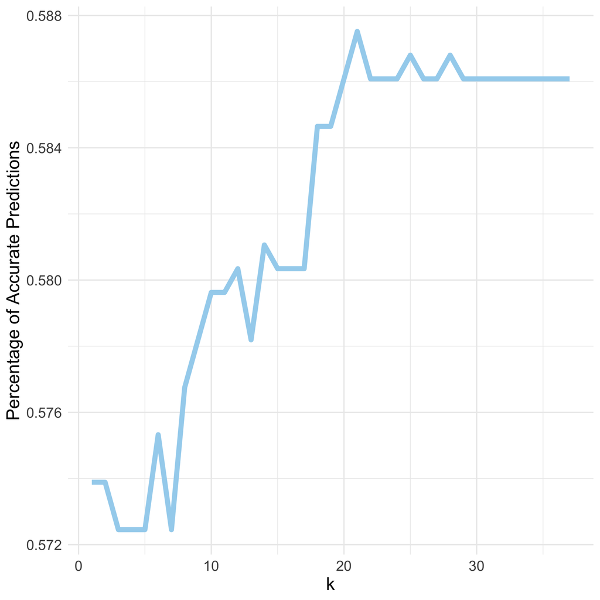

We also wanted to analyze how well source quality and the number of dead and missing migrants predict whether the incident occurred before or after Donald Trump’s inauguration. We put together a logistic regression model that would help us analyze relationships source quality and total dead missing have on post trump variable in our dataset. We chose these two predictors because after Donald Trump assumed office, there was greater media coverage of immigration into the U.S. With that, there were more reputable sources, which meant higher source quality for each reported incident. The train and test dataset of the model were created using the same procedure that we discussed in the kNN model.

# CONCLUSION

Moreover, the future data collection procedure could be improved if the data collected were for individual migrants rather than entire incidents. We could calculate the odds of dying on certain migration routes. Finally, future investigations and analyses are necessary to enact future policies to save the lives of migrants.